# Class 7: Machine Learning (Part I)

Mirte Ciz Marieke Kuijpers

09/02/2022

# R norm function

```r
# Investigate the rnorm() function using the help pages.
?rnorm
```

```
## starting httpd help server ... done
```

```r
# Test the rnorm() function
rnorm(10)
```

```
##  [1] -1.381520792  0.515746974  0.061218733  0.527795343  0.060793450
##  [6] -0.501864521 -0.748735592  0.008124484 -0.271323591 -0.760825565
```

```r
# Use some of the arguments with a default set value
rnorm(100, mean = 3)
```

```
##   [1] 2.1445436 2.6466863 4.0972332 1.9350249 2.5505269 2.2435948 1.8313892
##   [8] 1.7529606 2.1133038 3.4069474 4.3045114 2.0137686 5.2556009 1.2167021
##  [15] 3.9835138 3.7092739 2.1447756 1.4600349 4.9945324 3.4766551 3.8787110
##  [22] 1.7557507 3.9655817 4.1530376 4.2362019 3.4515057 4.2134900 2.7752967
##  [29] 2.0374594 3.2957304 1.5682297 3.6637638 3.6930591 3.0387279 1.1653263
##  [36] 3.5494999 2.8934927 1.7517903 3.2348971 3.5209474 3.5451014 2.7630448
##  [43] 4.2384176 4.0672233 2.8663734 2.7038909 3.7665895 1.6145842 4.2055827
##  [50] 2.7495199 3.1827260 3.2842156 3.2953429 2.5275170 2.2180529 4.6303152
##  [57] 2.2347902 2.1306556 4.3891929 2.6868329 1.9820820 4.2287145 3.5785952
##  [64] 3.7257096 3.2562212 4.8494330 3.2620266 2.9297341 2.3931699 3.5829448
##  [71] 2.5368996 2.2450510 1.2496852 3.2736569 4.6066588 3.3570098 0.9540308
##  [78] 3.1546742 2.2675874 3.3181002 1.8512750 3.6152612 1.2236817 2.3793787
##  [85] 3.8460848 2.7775950 3.3036578 2.0807018 1.9010793 2.8774776 3.4437130
##  [92] 2.1251089 2.2969592 1.6015999 3.3075832 4.2084612 0.3178379 2.0982384
##  [99] 1.9334393 1.6363209
```

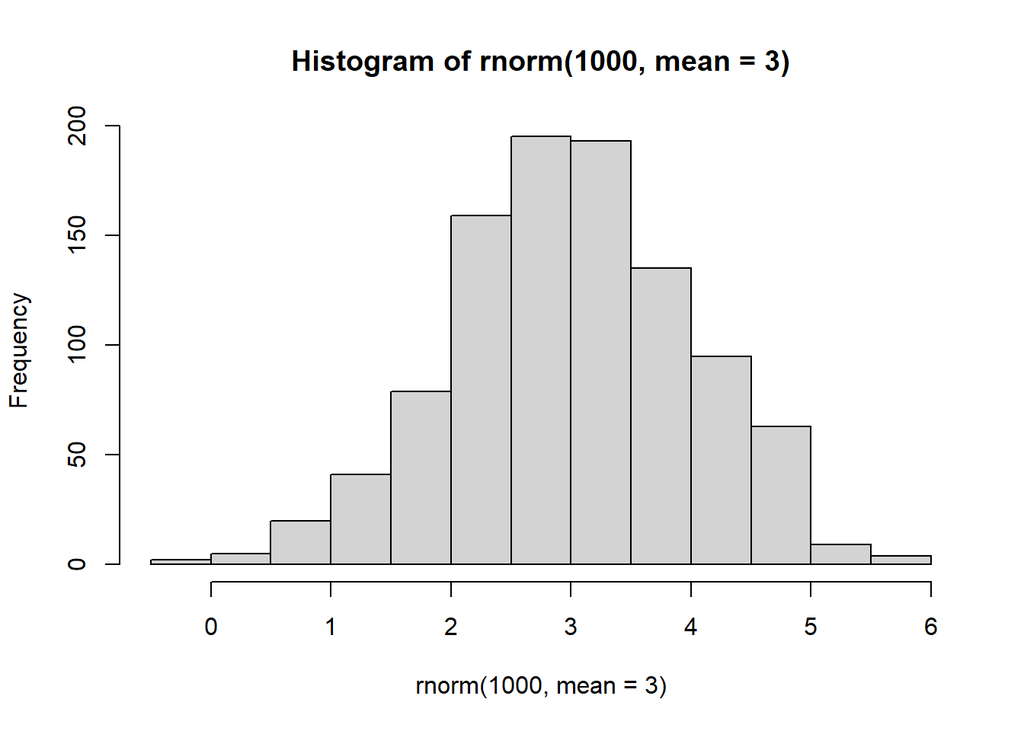

```r
# Plot some of these results

hist(rnorm(1000, mean = 3))
```

# Clustering methods

## Using the kmeans() function

Now that we understand rnorm()’s function, we can proceed to the example usage of kmeans(). The first step is to generate some example data to test the kmeans() function with.

```r
# Generate some random data
tmp <- c(rnorm(30, -3), rnorm(30, 3))
tmp
```

```
##  [1] -4.7268156 -2.3815400 -3.5145497 -4.4450921 -3.2063916 -3.2708725
##  [7] -3.3197633 -3.7182566 -4.1273200 -4.8861763 -2.0662823 -3.7084250
## [13] -2.8515963 -3.5321403 -2.6298575 -2.5734713 -2.0031711 -2.9991967
## [19] -3.3409822 -3.2731600 -3.5168983 -1.7544575 -1.3389466 -1.8931351
## [25] -2.5221782 -4.3947039 -2.8741952 -2.5881396 -3.9129993 -3.4692479
## [31]  2.1029178  1.1078144  4.0437064  3.3494490  4.0392822  3.1793533
## [37]  3.5841866  3.7526868  2.6003206  3.8561980  4.0078465  2.7032714
## [43]  3.2421416  3.3159749  1.5547593  0.7885683  2.4197159  3.3325406
## [49]  1.7033817  2.0839463  3.5159900  4.0776220  3.3209271  2.6366660
## [55]  2.4702877  3.7979770  1.8268729  3.3445229  3.8410022  2.6087716
```

```r
# Format the random data to be used by kmeans()
x <- cbind(x=tmp, y=rev(tmp))
x
```

```
##                x          y
##  [1,] -4.7268156  2.6087716
##  [2,] -2.3815400  3.8410022
##  [3,] -3.5145497  3.3445229
##  [4,] -4.4450921  1.8268729
##  [5,] -3.2063916  3.7979770
##  [6,] -3.2708725  2.4702877
##  [7,] -3.3197633  2.6366660
##  [8,] -3.7182566  3.3209271
##  [9,] -4.1273200  4.0776220
## [10,] -4.8861763  3.5159900
## [11,] -2.0662823  2.0839463
## [12,] -3.7084250  1.7033817
## [13,] -2.8515963  3.3325406
## [14,] -3.5321403  2.4197159
```

[output cut: 46 more lines]

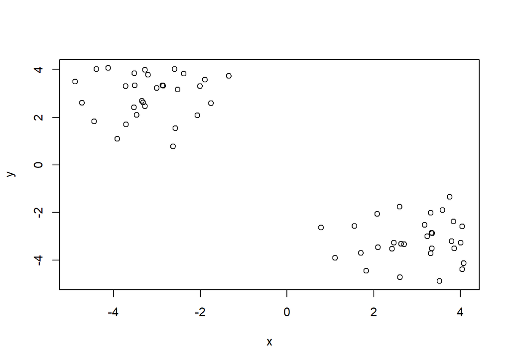

```r
# Plot data to get a feel for the distribution
plot(x)
```

Note that the data above is randomly generated each time the code chunk is run. Therefore, the plot and all answers relying on this data will vary slightly each time the code is re-initialised. Now we can use the kmeans() function to cluster this random data.

```r
# Cluster the data using the kmeans method
k <- kmeans(x, centers = 2, nstart = 10) # nstarts represents number of new starts (i.e. iterations) to run
k
```

```
## K-means clustering with 2 clusters of sizes 30, 30
##
## Cluster means:
##           x         y
## 1  2.940290 -3.161332
## 2 -3.161332  2.940290
##
## Clustering vector:
##  [1] 2 2 2 2 2 2 2 2 2 2 2 2 2 2 2 2 2 2 2 2 2 2 2 2 2 2 2 2 2 2 1 1 1 1 1 1 1 1
## [39] 1 1 1 1 1 1 1 1 1 1 1 1 1 1 1 1 1 1 1 1 1 1
##
## Within cluster sum of squares by cluster:
## [1] 47.4439 47.4439
##  (between_SS / total_SS =  92.2 %)
##
## Available components:
##
## [1] "cluster"      "centers"      "totss"        "withinss"     "tot.withinss"
## [6] "betweenss"    "size"         "iter"         "ifault"
```

If we want to know how many points are in each cluster use the size values within k. Other interesting data can also be extracted from the variable containing the kmeans() results.

```r
# Find the number of points in each group
k$size
```

```
## [1] 30 30
```

```r
# To find the centroids use:
k$centers
```

```
##           x         y
## 1  2.940290 -3.161332
## 2 -3.161332  2.940290
```

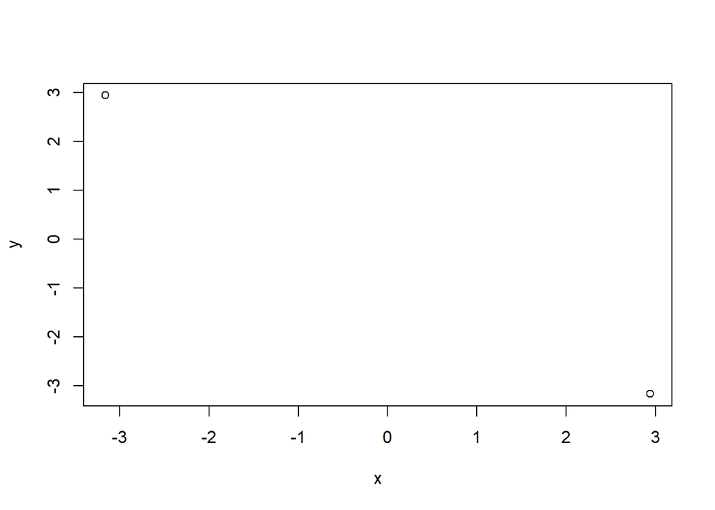

```r
# You can also plot them
plot(k$centers)
```

The membership vector, assigning each point to a cluster, is perhaps the most important results, as it allows you to analyse how your points are clustered.

```r
# Print the cluster vector
k$cluster
```

```
##  [1] 2 2 2 2 2 2 2 2 2 2 2 2 2 2 2 2 2 2 2 2 2 2 2 2 2 2 2 2 2 2 1 1 1 1 1 1 1 1
## [39] 1 1 1 1 1 1 1 1 1 1 1 1 1 1 1 1 1 1 1 1 1 1
```

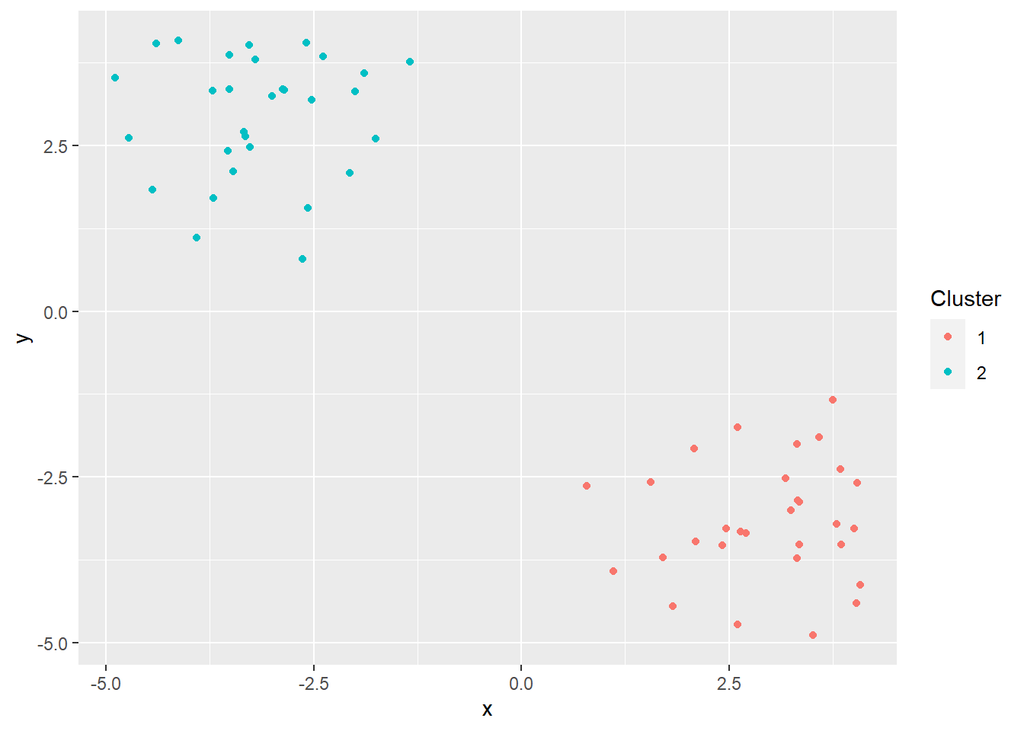

```r
# Plot the points coloured by these clusters

# Load ggplot2 library
library(ggplot2)

# Put data into a format ggplot can use
dat <- as.data.frame(cbind(x, k$cluster))
colnames(dat) <- c("x", "y", "cluster")

# Plot the data
ggplot(dat, aes(x, y, colour = as.factor(cluster))) +
  geom_point() +
  labs(colour = "Cluster")
```

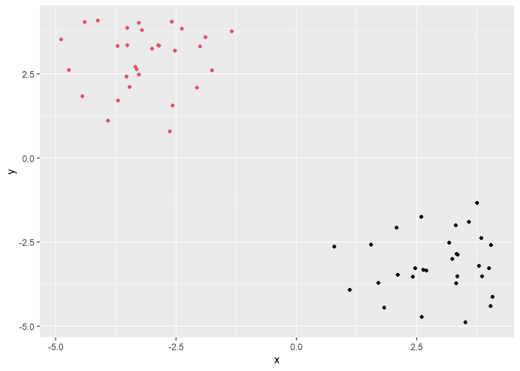

```r
# In actual fact, one does not need to consolidate the data, one can simply use k$cluster outside the aes(), provided that k$cluster and x stay in the same order, the data will remain correctly correlated with the colours
ggplot(as.data.frame(x), aes(x,y)) +
  geom_point(col = k$cluster)
```

## hclust() function

kmeans() uses Euclidean distance, hclust can use various similarity/difference measures, which is useful, but requires extra input. hclust() requires data already as distances between points (a dissimilarity/similarity matrix), not the raw data. One way to do so is to use the dist() function.

```r
# Use the hclust() function on the same data (x) used for investigating the kmeans() function
hc <- hclust(dist(x))
hc
```

```
##
## Call:
## hclust(d = dist(x))
##
## Cluster method   : complete
## Distance         : euclidean
## Number of objects: 60
```

While the output for hclust(), when printed, is not as useful as for kmeans(), it has a custom plot method which helps interpret the data. In the dendrogram produced, the height of the crossbars represents (or is proportional to) the distance between the two groups joined by said crossbar.

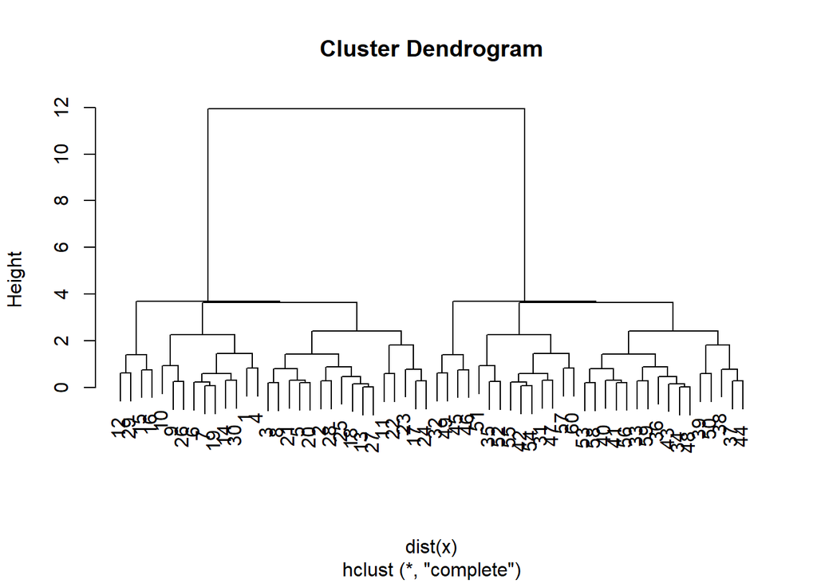

```r
# Plot hclust() data, as printing the output is not as useful as for kmeans()
plot(hc)
```

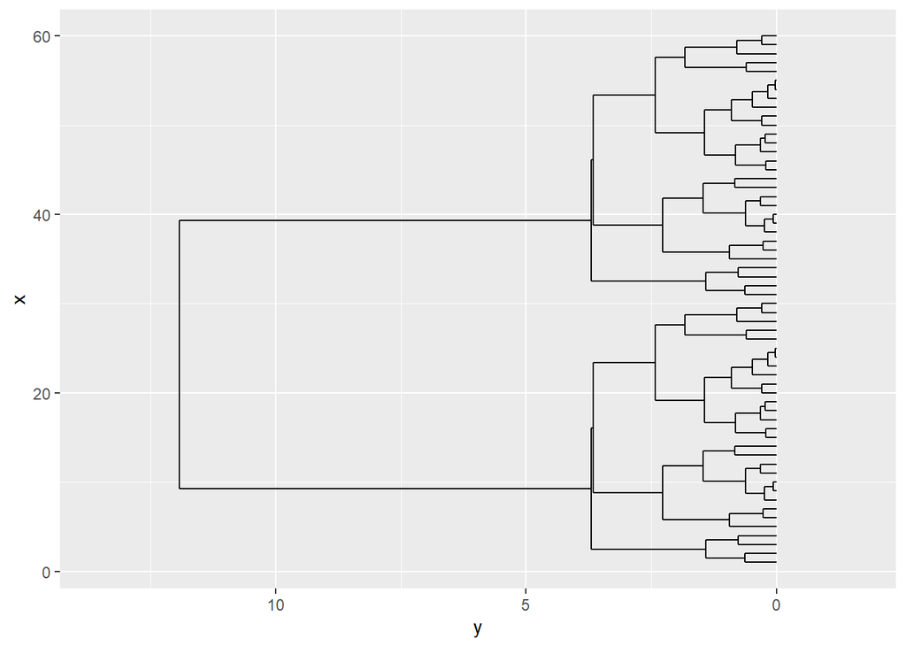

```r
# One can also plot with ggplot, if a wrapper for dendrograms is also loaded:
library(ggdendro)

# Convert the data into a format ggplot can use - code borrowed from the following tutorial https://cran.r-project.org/web/packages/ggdendro/vignettes/ggdendro.html
ghc <- as.dendrogram(hc)

ghc_dat <- dendro_data(ghc, type = "rectangle")

ggplot(segment(ghc_dat)) +
  geom_segment(aes(x = x, y = y, xend = xend, yend = yend)) +
  coord_flip() +
  scale_y_reverse(expand = c(0.2, 0))
```

To determine groups, one can set a horizontal cut-off line, which separates points connected below that cut-off into clusters.

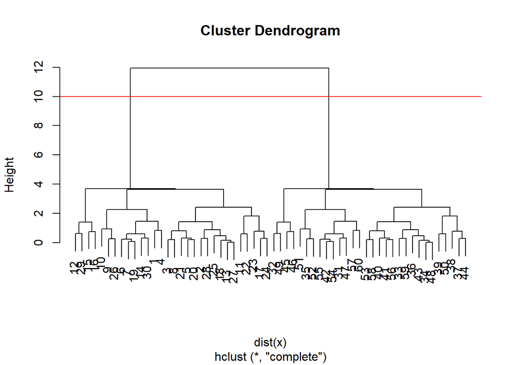

```r
plot(hc)
abline(h = 10, col = "Red")
```

Instead of adding this cut-off line, we can use `cutree()`, a function specifically for this.

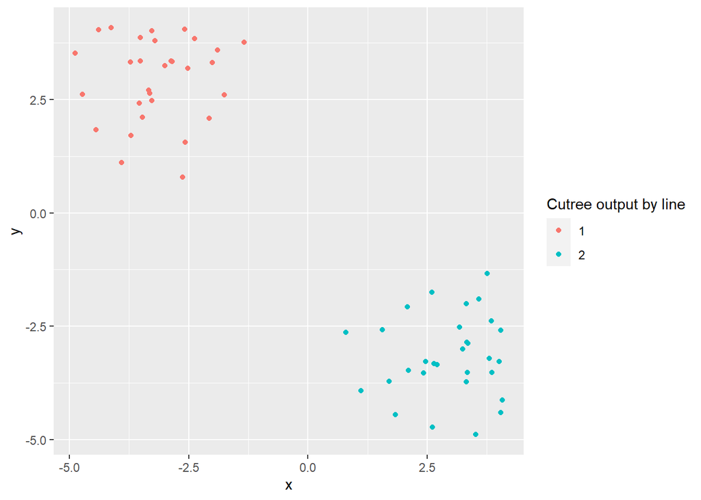

```r
cth <- cutree(hc, h=10)
#or specify the number of groups
ctk <- cutree(hc, k=2)

# Put data into a format ggplot can use
dat <- as.data.frame(cbind(x, cth, ctk))
colnames(dat) <- c("x", "y", "cth", "ctk")

# Plot the data
ggplot(dat, aes(x, y, colour = as.factor(cth))) +
  geom_point() +
  labs(colour = "Cutree output by line")
```

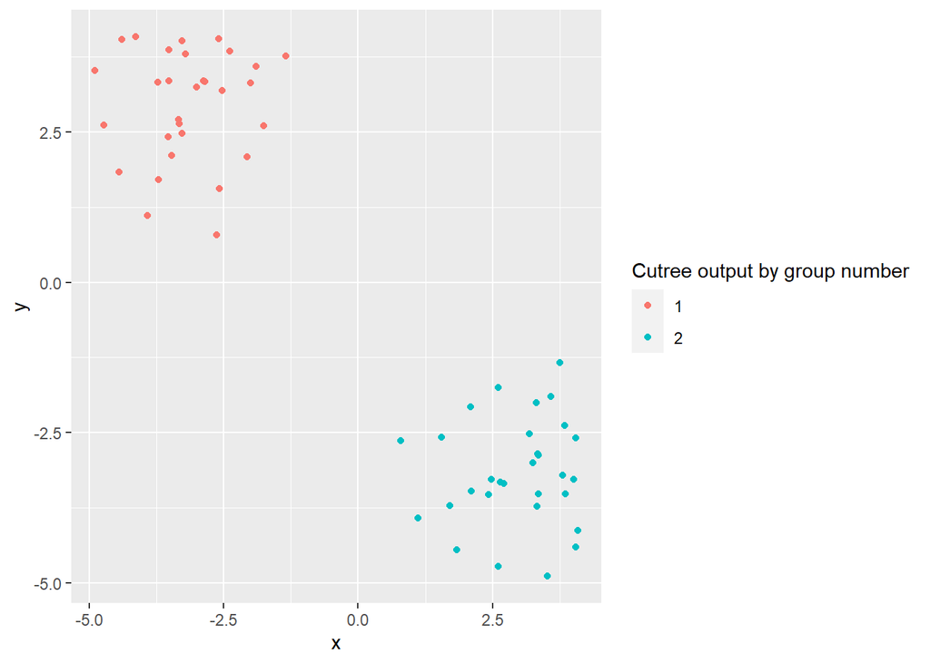

```r
ggplot(dat, aes(x, y, colour = as.factor(ctk))) +
  geom_point() +
  labs(colour = "Cutree output by group number")
```